# PEC3 PABLO

## 5)

```r
diabetes_filtrado = diabetes %>%
    filter(
        Glucose != 0,
        BloodPressure != 0,
        SkinThickness != 0,
        Insulin != 0,
        BMI != 0
    )

# Cantidad de registros de la base de datos filtrada
nrow(diabetes_filtrado)
```

```
## [1] 392
```

```r
# Representatividad de personas con diabetes y sin ella
table(diabetes_filtrado$Outcome)
```

```
##
##   0   1
## 262 130
```

```r
prop.table(table(diabetes_filtrado$Outcome))
```

```
##
##         0         1
## 0.6683673 0.3316327
```

Calculamos la matriz de correlación del conjunto de datos y la representación gráfica que muestre la relación de todas las variables.

```r
corr = cor(diabetes_filtrado)
print(corr)
```

```
##                           Pregnancies   Glucose BloodPressure SkinThickness
## Pregnancies               1.000000000 0.1982910     0.2133548     0.0932094
## Glucose                   0.198291043 1.0000000     0.2100266     0.1988558
## BloodPressure             0.213354775 0.2100266     1.0000000     0.2325712
## SkinThickness             0.093209397 0.1988558     0.2325712     1.0000000
## Insulin                   0.078983625 0.5812230     0.0985115     0.1821991
## BMI                      -0.025347276 0.2095159     0.3044034     0.6643549
## DiabetesPedigreeFunction  0.007562116 0.1401802    -0.0159711     0.1604985
## Age                       0.679608470 0.3436415     0.3000389     0.1677611
## Outcome                   0.256565956 0.5157027     0.1926733     0.2559357
##                             Insulin         BMI DiabetesPedigreeFunction
## Pregnancies              0.07898363 -0.02534728              0.007562116
## Glucose                  0.58122301  0.20951592              0.140180180
## BloodPressure            0.09851150  0.30440337             -0.015971104
## SkinThickness            0.18219906  0.66435487              0.160498526
## Insulin                  1.00000000  0.22639652              0.135905781
## BMI                      0.22639652  1.00000000              0.158771043
## DiabetesPedigreeFunction 0.13590578  0.15877104              1.000000000
## Age                      0.21708199  0.06981380              0.085029106
## Outcome                  0.30142922  0.27011841              0.209329511
##                                 Age   Outcome
## Pregnancies              0.67960847 0.2565660
## Glucose                  0.34364150 0.5157027
## BloodPressure            0.30003895 0.1926733
## SkinThickness            0.16776114 0.2559357
## Insulin                  0.21708199 0.3014292
## BMI                      0.06981380 0.2701184
## DiabetesPedigreeFunction 0.08502911 0.2093295
## Age                      1.00000000 0.3508038
## Outcome                  0.35080380 1.0000000
```

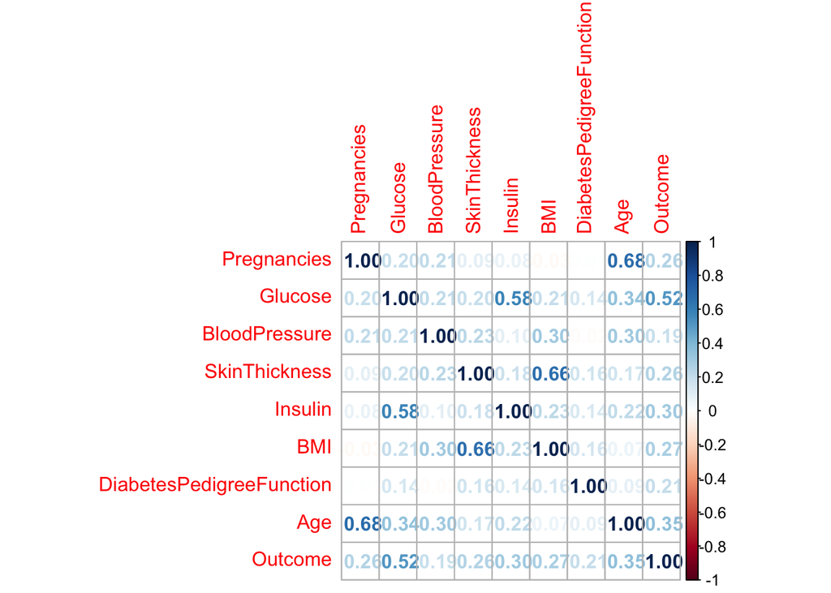

```r
library(corrplot)
corrplot(corr,method = "number")
```

```r
model = lm(Glucose ~ Age + BMI, data = diabetes_filtrado)
summary(model)
```

```
##
## Call:
## lm(formula = Glucose ~ Age + BMI, data = diabetes_filtrado)
##
## Residuals:
##     Min      1Q  Median      3Q     Max
## -72.743 -19.207  -3.631  18.212  83.122
##
## Coefficients:
##             Estimate Std. Error t value Pr(>|t|)
## (Intercept)  64.6675     7.9508   8.133 5.66e-15 ***
## Age           1.0003     0.1415   7.067 7.37e-12 ***
## BMI           0.8187     0.2055   3.985 8.06e-05 ***
## ---
## Signif. codes:  0 '***' 0.001 '**' 0.01 '*' 0.05 '.' 0.1 ' ' 1
##
## Residual standard error: 28.48 on 389 degrees of freedom
## Multiple R-squared:  0.1527, Adjusted R-squared:  0.1483
## F-statistic: 35.05 on 2 and 389 DF,  p-value: 1.013e-14
```

En este modelo de regresión lineal se está intentando predecir el nivel de Glucosa en sangre en función de la edad y el índice de masa corporal (BMI) de los pacientes. Los resultados indican que existe una relación estadísticamente significativa entre estas variables (p-valor < 0.05). El coeficiente de Age es 1.0003, lo que significa que a medida que la edad de un paciente aumenta en 1 unidad, se espera que su nivel de Glucosa aumente en 1.0003 unidades. El coeficiente de BMI es 0.8187, lo que significa que a medida que el BMI de un paciente aumenta en 1 unidad, se espera que su nivel de Glucosa aumente en 0.8187 unidades. El R cuadrado es 0.1527, lo que significa que estas dos variables explican el 15.27% de la variación en el nivel de Glucosa. Sin embargo, este modelo es solo una aproximación y es importante tener en cuenta otros factores que pueden influir en el nivel de Glucosa.

## 7)

Utilizaré las variables del apartado 5 para realizar el análisis ANOVA ya que son las mas prometedoras de las que tienen un sentido lógico e interpretable.

```r
model = aov(Glucose ~ Age + BMI, data = diabetes_filtrado)
summary(model)
```

```
##              Df Sum Sq Mean Sq F value   Pr(>F)
## Age           1  43975   43975   54.21 1.08e-12 ***
## BMI           1  12880   12880   15.88 8.06e-05 ***
## Residuals   389 315529     811
## ---
## Signif. codes:  0 '***' 0.001 '**' 0.01 '*' 0.05 '.' 0.1 ' ' 1
```

Los resultados del ANOVA muestran que tanto la edad como el índice de masa corporal (BMI) tienen un efecto significativo en la variable dependiente (en este caso, GLucose). Esto se deduce de los valores p muy pequeños y de los asteriscos junto a las variables “Age” y “BMI” en la columna “Pr(>F)”.

El valor F en sí mismo también es significativo, lo que indica que hay una diferencia significativa entre los promedios de la variable dependiente para los diferentes grupos de edad y BMI.

Para ver si existe un fuerte agrupamiento entre las variables, puedomos usar *hclust* para generar un dendrograma. Esto ayudará a visualizar cómo están relacionadas las variables y si existen subgrupos o clústeres evidentes.

Para generar un dendrograma, primero necesitamos calcular la distancia entre las variables. Lo podemos hacer con la función *dist*:

```r
distance = dist(diabetes_filtrado[, c("Age", "BMI", "Glucose")])
cluster = hclust(distance)
summary(cluster)
```

```
##             Length Class  Mode
## merge       782    -none- numeric
## height      391    -none- numeric
## order       392    -none- numeric
## labels        0    -none- NULL
## method        1    -none- character
## call          2    -none- call
## dist.method   1    -none- character
```

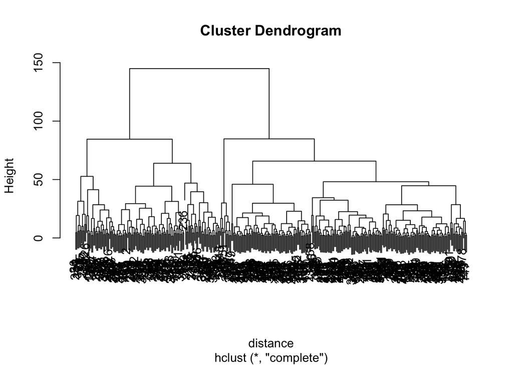

```r
plot(cluster)
```